# Week 15：广义线性模型（GLM）核心

**主题**：`Logistic Regression`

**本节课主线**：

- 为什么二分类任务不能直接把 `OLS` 硬套上去？
- `sigmoid`、`Bernoulli` 和 `MLE` 是怎样自然连起来的？
- `log-odds` 为什么让逻辑回归的系数变得可解释？
- 为什么分类问题不能只看 `accuracy`？
- 为什么正则化逻辑回归在工业界一直不过时？

## 目录

这节课一共有 6 幕：

1. 为什么分类不能直接拿 `OLS` 硬做？
2. 如果要预测概率，`sigmoid` 为什么自然？
3. 为什么这里自然会走到 `Bernoulli + MLE`？
4. `log-odds` 到底是什么，系数为什么能解释？
5. 分类指标为什么不能只看 `accuracy`？
6. 正则化逻辑回归为什么一直不过时？

这 6 幕之间的关系可以压成一句话：

> 我们先证明“普通回归不适合直接做分类”， 再一步步回答：如果还想保留线性结构， 输出该怎么改、分布该怎么改、目标函数该怎么改、解释该怎么改， 最后再讨论工业界为什么仍然离不开逻辑回归。

## Prologue：这节课真正要讨论的，不是“会不会分类”，而是“怎么正确地建模概率”

上周我们还在做连续响应下的回归问题。 但现实里还有一大类任务，响应变量不是一个连续数值，而是：

- 是否违约；
- 是否流失；
- 是否点击；
- 是否患病。

这些任务的共同点是：

- 响应变量常常只有 `0/1`；
- 我们更关心“发生的概率”；
- 模型不仅要给出分类结果，还要给出可解释的风险信号。

所以如果还想沿用回归框架，直觉上只有两条路：

- 要么直接用线性模型去拟合 $y \in \{0,1\}$；
- 要么先回归出一个连续值，再把这个连续值硬解释成概率。

这两条路听起来都很顺手，但其实都埋着问题。

所以这节课的核心不是“又学一个新算法”，而是：

> 当响应变量变成 `0/1` 时，回归框架要怎样改造，才既保留线性结构，又符合概率建模？

## 第一幕：分类问题为什么不能直接拿 `OLS` 硬做？

这一幕先不急着定义逻辑回归。 先让大家对一件事感到不舒服：

> 如果标签只有 `0/1`，普通线性回归到底哪里不自然？

先猜：

如果我们把一个二分类任务直接交给 `OLS`，你觉得最先出问题的会是：

1. 预测值可能跑出 `[0,1]`；
2. 模型完全不能分开两类；
3. 两者都会。

**本幕主图**：同一份 `0/1` 数据上，`OLS` 预测值与逻辑回归概率曲线对比

这张图要回答：

> 即使线性回归偶尔能“看起来分得开”，为什么它仍然不适合直接充当概率模型？

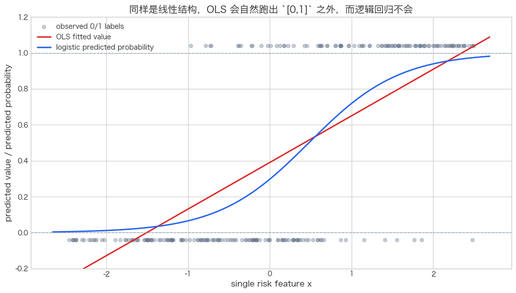

图里最别扭的地方有两个：

- `OLS` 输出的是实数，所以可能给出大于 `1` 或小于 `0` 的预测；
- 即使局部看起来能分开两类，它也不是在按“概率模型”的方式训练自己。

**把直观和严格定义对应起来**

在二分类问题里，我们面对的是：

$$ Y \in \{0,1\} $$

如果还直接写

$$ E[Y \mid X] = X\beta $$

那么右边作为线性预测量可以取任意实数，就天然会遇到边界问题： 它并不保证输出落在概率应该属于的区间 `[0,1]` 里。

**顺手回顾一下：分类和回归最本质的区别是什么？**

- 回归问题里，响应变量通常是连续数值；
- 分类问题里，响应变量是离散标签。

这听起来像一句废话，但其实我们早就见过它的后果： 在做 `one-hot encoding` 时，我们已经看到“离散变量”一旦进入建模流程， 就不能再被当作普通连续量随意处理。

只不过那时这个区别出现在 `X` 的范畴里； 这周，这个区别第一次直接落在 `Y` 的范畴里。

这里，大家需要记住的是：

- 分类任务不是不能保留“线性预测”；
- 但不能继续把输出直接当作一个无边界实数；
- 所以逻辑回归的第一步，不是换掉线性部分，而是换掉“输出如何被解释”。

## 第二幕：如果要预测概率，为什么 `sigmoid` 很自然？

既然问题出在“输出不该再是任意实数”，一个自然问题就是：

> 如果我们还想保留线性部分 $\eta = X\beta$，怎样把它稳定地映射到 `[0,1]`？

先猜：

如果一个模型先算出线性预测量 $\eta$，然后再把它变成概率， 你觉得这个映射最重要的性质是什么？

1. 对输入没有额外限制；
2. 输出必须落在 `[0,1]`；
3. 两者都必须满足。

**本幕主图**：`sigmoid` 如何把线性预测量压成概率

这张图要回答：

> 为什么大家一讲逻辑回归就会提到 `sigmoid`？

先把定义放在前面：

$$ \sigma(\eta) = \frac{1}{1 + e^{-\eta}} $$

它有两个最关键的性质：

- 对输入 $\eta$ 没有额外限制；
- 输出稳定落在 $(0,1)$，因此可以被解释成概率。

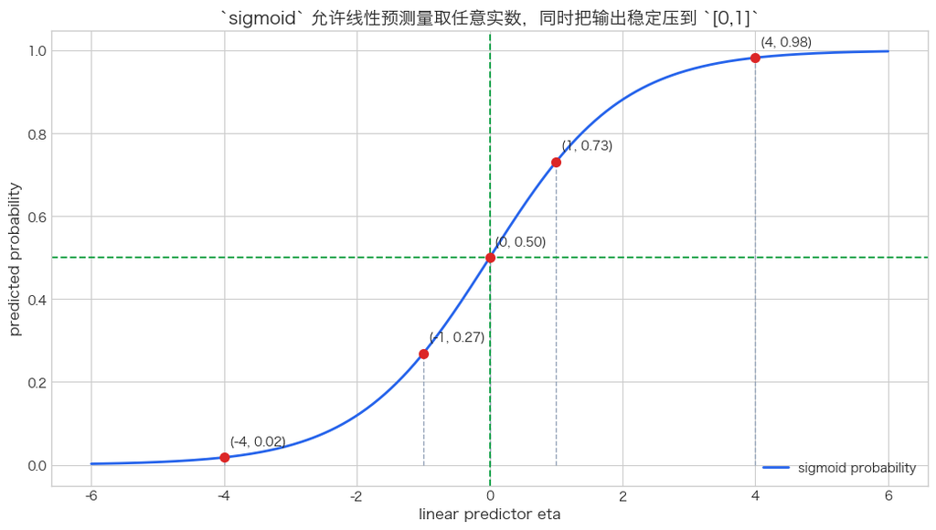

从图上可以直接读出三件事：

- $\eta$ 很大时，概率接近 `1`；
- $\eta$ 很小时，概率接近 `0`；
- $\eta = 0$ 正好对应 $p = 0.5$。

**把直观和严格定义对应起来**

逻辑回归保留了线性预测子：

$$ \eta = X\beta $$

但不直接把 $\eta$ 当作输出，而是通过 `sigmoid` 把它映射成概率：

$$ p(x) = \frac{1}{1 + e^{-\eta}} $$

所以更准确的说法是： **线性预测量先算出来，再被 link function 压成概率。**

这里，大家需要记住的是：

- 逻辑回归并没有抛弃线性结构；
- 它是在“线性预测量”外面，加了一个把输出压成概率的映射；
- 所以逻辑回归更准确的说法是：**线性预测 + 概率映射**。

## 第三幕：为什么这里自然会走到 `Bernoulli + MLE`？

一旦输出被解释成概率，接下来的问题就是：

> 那我们到底该用什么分布、什么目标函数来训练这个模型？

先问一个更基础的子问题：

如果我们现在已经把输出压成了概率， 那还能不能继续像普通回归那样，用 `RMSE / MSE` 作为损失函数？

很多人第一反应会说： “为什么不行？反正真值还是 `0/1`，预测值还是一个数。”

这一幕就是要回答：**这里为什么更自然地转向 `Bernoulli + MLE`。**

**先把对象定义清楚**

这里我们不是在做“带阈值的回归”，而是在做概率建模。

如果记

$$ Y \sim Bernoulli(p) $$

那么单个样本的 likelihood 就是：

$$ L(p; y) = p^y (1-p)^{1-y} $$

也就是说：

- 当 $y = 1$ 时，我们希望 $p$ 尽量大；
- 当 $y = 0$ 时，我们希望 $p$ 尽量小。

**本幕主图**：为什么这里不再优先使用平方误差？

这张图要回答：

> 如果输出已经被解释成概率，那么平方误差和基于似然的损失，到底在惩罚什么？

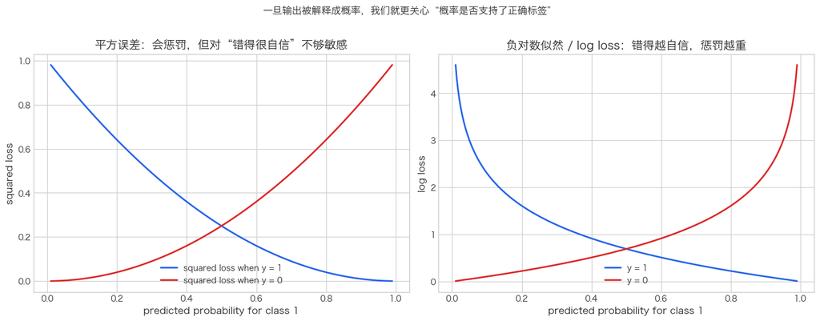

**这张图的纵轴和图像含义怎么读？**

- 左图纵轴是“损失大小”：越高表示这个概率预测越糟；
- 右图纵轴也是“损失大小”，但它来自负对数似然；
- 两张图都在看：给定真值后，不同预测概率会受到怎样的惩罚。

真正关键的区别是：

- 平方误差当然也会惩罚错误；
- 但当你把错误概率压得特别极端时，它的惩罚仍然是有上界的；
- 负对数似然会对“错得很自信”给出更重的惩罚。

**把直观和严格定义对应起来**

如果从 `Bernoulli likelihood` 出发， 把所有样本的 likelihood 乘起来，再取对数， 就得到逻辑回归训练时使用的对数似然； 再乘一个负号，得到的正是大家常见的 `log loss` / 交叉熵目标。

所以这里不是“先研究了半天 log loss，后来才顺手说它和 likelihood 有关”； 而是：

$$ Bernoulli \ probability \ model \Longrightarrow likelihood \Longrightarrow negative\ log\ likelihood = log\ loss $$

这里，大家需要记住的是：

- 严格说，平方误差并不是“绝对不能用”，但它不是这里最自然的统计目标；
- 逻辑回归从一开始就在建模 `Bernoulli` 概率；
- 所以它的训练目标自然来自 `MLE`，也就是负对数似然 / `log loss`。

## 第四幕：`log-odds` 到底是什么，系数为什么能解释？

到这里，概率已经出来了。 但逻辑回归真正最强的一点，还不是“会给概率”，而是：

> 它的系数仍然可以被解释，只不过解释落在 `log-odds` 上。

先猜：

很多人第一次见逻辑回归时，都会很自然地想：

> 如果模型最后输出的是概率，那系数能不能直接解释成“概率加多少”？

这个直觉很自然，但恰恰不对。 所以下一页我们要把注意力集中到：

> 为什么逻辑回归的系数解释，不能直接落在概率上？

也就是说，为什么它不会直接说成：

> `x` 增加 1，概率就增加 `beta` 这么多？

你直觉上觉得，问题更可能出在：

1. 概率本身有边界；
2. 概率和自变量的关系不是线性的；
3. 两者都对。

**先把定义放在前面**

我们先定义：

$$ odds = \frac{p}{1-p} $$

再定义：

$$ logit(p) = \log\left(\frac{p}{1-p}\right) $$

逻辑回归真正写成线性形式时，是：

$$ logit(p) = X\beta $$

也就是说，这一幕接下来讨论的对象，从一开始就是： **odds / log-odds，而不是概率本身。**

**本幕主图**：概率、odds、log-odds 的对应关系

这张图要回答：

> 为什么逻辑回归真正线性的是 `log-odds`，而不是概率本身？

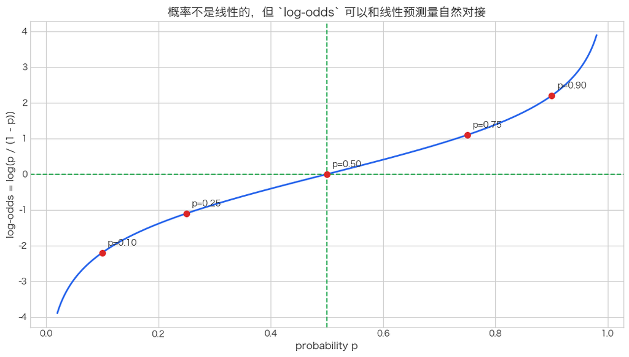

|  | probability p | odds = p / (1-p) | log-odds |
| --- | --- | --- | --- |
| 0 | 0.10 | 0.11 | -2.2 |
| 1 | 0.25 | 0.33 | -1.1 |
| 2 | 0.50 | 1.00 | 0.0 |
| 3 | 0.75 | 3.00 | 1.1 |
| 4 | 0.90 | 9.00 | 2.2 |

**系数解释落在哪里？**

一旦写成

$$ logit(p) = X\beta $$

系数的解释就变成：

- `x_j` 增加 1 单位；
- 其他变量不变时；
- `log-odds` 会改变 $\beta_j$。

如果想转成更业务的说法，可以进一步看：

$$ \exp(\beta_j) $$

它表示 odds 会被乘上多少倍。

这里，大家需要记住的是：

- 逻辑回归真正线性的是 `log-odds`，不是概率本身；
- 因此系数的统计解释是：自变量变化如何影响 `log-odds`；
- 对业务方来说，更自然的翻译通常是：某个变量会让“发生的相对可能性”上升还是下降。

## 第五幕：分类指标为什么不能只看 `accuracy`？

到这里，模型形式已经立住了。 但如果只会报一个 `accuracy`，分类任务仍然很容易被讲得过于粗糙。

先猜：

如果我们在做违约预警、欺诈检测、用户流失这样的任务， 你觉得下面哪件事更危险？

1. 总体准确率不是特别高；
2. 真正危险的样本经常没被抓出来。

**本幕主图**：threshold 改变时，`accuracy` 与 `recall` 会怎么变？

这张图要回答：

> 为什么分类器不是只给一个结果，还要讨论阈值和指标偏好？

**先把定义放在前面**

在分类任务里，最基础的对象是混淆矩阵：

- `TP`：把正类判成正类；
- `TN`：把负类判成负类；
- `FP`：把负类误判成正类；
- `FN`：把正类漏判成负类。

从这里往上，至少有两层指标：

- 一级：`TP / TN / FP / FN` 这四个计数；
- 二级：`accuracy`、`precision`、`recall`、`F1`；
- 再往上还有 `ROC-AUC` 和 `log loss` 这种更整体的概率 / 排序型指标。

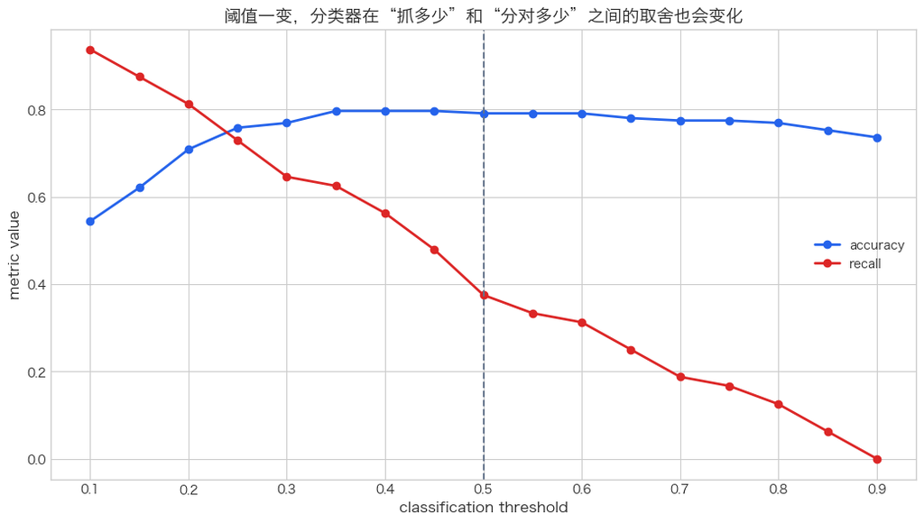

|  | model | threshold | accuracy | recall | roc_auc | log_loss | model_size |
| --- | --- | --- | --- | --- | --- | --- | --- |
| 0 | Logistic @ 0.5 | 0.5 | 0.791 | 0.375 | 0.819 | 0.438 | None |
| 1 | Logistic @ 0.3 | 0.3 | 0.769 | 0.646 | 0.819 | 0.438 | None |
| 2 | Base-rate only | 0.5 | 0.736 | 0.000 | 0.500 | 0.577 | None |

**把定义和图重新接起来**

这节课至少要把 6 个指标分开：

- `accuracy`：总共分对了多少；
- `precision`：判成正类的样本里，真的有多少是正类；
- `recall`：真正应该抓住的正类，抓住了多少；
- `F1`：`precision` 和 `recall` 的调和平均；
- `ROC-AUC`：模型把正类排在负类前面的整体能力；
- `log loss`：模型给出的概率分布是否靠谱，尤其会重罚“错得很自信”的情况。

这里，大家需要记住的是：

- 分类指标不是彼此替代，而是在回答不同问题；
- 逻辑回归的概率输出，使它非常适合和阈值、风险偏好、概率损失联系起来；
- 所以评估分类器时，不能只盯着“分对了多少个”。

## 第六幕：正则化逻辑回归为什么在工业界一直不过时？

到这里，终于可以把这周和 week13 真正接起来了：

> 如果逻辑回归也面对高维、相关特征和过拟合风险，它当然也会需要正则化。

先猜：

在高维分类里， 你觉得 `L1` 和 `L2` 的“性格”会不会和在线性回归里很像？

1. `L1` 更偏稀疏筛选；
2. `L2` 更偏平滑收缩；
3. 两者都会，只是强度不同。

**本幕主图**：高维分类里，`L1` 与 `L2` 逻辑回归的系数与指标对比

这张图要回答：

> 为什么逻辑回归即使不复杂，仍然是一个非常强的工业 baseline？

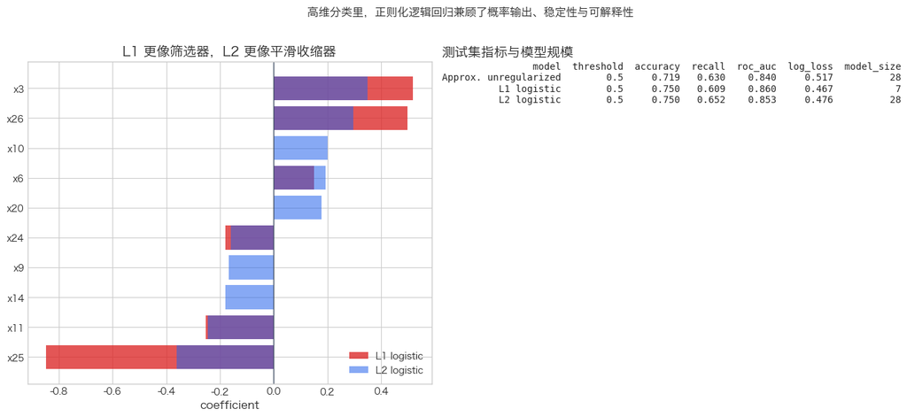

这张图里至少要看两层对比：

- 左边：`L1` 更容易把很多系数直接压到 `0`，`L2` 更倾向于整体收缩；
- 右边：即使指标差距不夸张，模型规模和解释风格也会非常不同。

**把直观和严格定义对应起来**

逻辑回归一旦加入正则化，目标函数就变成：

$$ \text{negative log-likelihood} + \lambda \cdot penalty(\beta) $$

其中：

- `L1` penalty 更容易产生稀疏解，适合做高维分类里的特征筛选；
- `L2` penalty 更偏向平滑收缩，适合在相关特征存在时稳定估计。

所以在线性回归里学到的“`L1` vs `L2` 性格差异”，在逻辑回归里仍然保留。

这里，大家需要记住的是：

- 逻辑回归不是过时模型，而是非常强的 baseline 和解释工具；
- `L1` 更适合稀疏筛选，`L2` 更适合稳定收缩；
- 在很多工业场景里，“可解释 + 可校准 + 可快速部署”本身就是重要优势。

## Synthesis

今天整节课其实都在回答同一个问题：

> 当响应变量从连续值变成 `0/1` 时，回归框架要怎样改造，才能既保留线性结构，又符合概率建模？

到这里，大家需要记住 6 个判断：

1. 分类任务不能继续把输出直接当作无边界实数；
2. `sigmoid` 让线性预测量自然映射到概率；
3. 一旦输出被解释成概率，`Bernoulli + MLE` 就会自然接上；
4. 逻辑回归真正线性的是 `log-odds`，所以系数仍然可解释；
5. 分类评估不能只看 `accuracy`，还要结合 recall、ROC-AUC、log loss；
6. 正则化逻辑回归在高维分类里仍然是很强的工业 baseline。

## Transition

今天我们看到：当响应变量是 `0/1` 时， `Bernoulli + logit link` 会把线性预测框架改造成逻辑回归。

这就自然引出一个更大的问题：

> 如果响应变量不是二分类，而是计数、比例，或者多类别，GLM 该怎样继续扩展？

下一个自然方向就是：

- 更一般的 `GLM`
- 不同分布与不同 link function 的对应关系
- 以及更复杂的分类建模形式